# Packages 2024 Wrapped

r-pkg

A late look at my R package updates from 2024.

Author

[Christopher T. Kenny](https://christophertkenny.com)

Published

March 21, 2025

[figure not shown]

It’s tax season, so I’m thinking about the past year. I never wrote a wrap up for 2024 on packages like [I had done for 2023](https://christophertkenny.com/posts/2023-12-21-cran-wrapped/). So, here’s a late look at my R package updates from 2024.

# Updates on CRAN

## New packages

I’ve added six new package to CRAN this year, up from five in 2023. My hope is that this is going to settle down a bit in 2025, but there’s quite a bit of work in progress already…

### `alarmdata`

[figure not shown]

[`alarmdata`](https://alarm-redist.org/alarmdata/) provides an interface to data from the [ALARM Project](https://alarm-redist.org/). This gives a simple way to download data on things like congressional districts or precinct election results.

### `planscorer`

[figure not shown]

[`planscorer`](https://christophertkenny.com/planscorer/) is an R port (plus a little extra) of the python package for [PlanScore](https://planscore.org/). PlanScore is a tool for evaluating redistricting plans, particularly for partisan fairness. `planscorer` allows you to upload a plan to PlanScore and get back a report on the plan’s partisan fairness.

### `redistverse`

[figure not shown]

The [`redistverse`](https://alarm-redist.org/redistverse/) is a collection of packages for redistricting, centered on the award-winning R package, [`redist`](https://alarm-redist.org/redist/). This combines many of our packages for redistricting, like `redist`, `redistmetrics`, `geomander`, `ggredist`, `censable`, `tinytiger`, `PL94171`, and `alarmdata` into one easy-to-install bundle.

### `palette`

[figure not shown]

[`palette`](https://christophertkenny.com/palette/) is a package for creating color palettes. It’s based on the [`vctrs`](https://vctrs.r-lib.org/) package, so it’s easy to use with the tidyverse. My hope is that this will be a useful tool for creating consistent color schemes across projects by providing basic methods for creating palettes.

### `baf`

[figure not shown]

[`baf`](https://christophertkenny.com/baf/) is a package for accessing Block Assignment Files (BAFs) from the US Census Bureau. These files crosswalk blocks from the decennial census to other geographies, like congressional districts or state legislative districts.

### `opengraph`

[figure not shown]

[`opengraph`](https://christophertkenny.com/opengraph/) is a package for reading metadata from web pages. With the Open Graph Protocol, many websites provide structured data about their pages. This allows packages like [`bskyr`](https://christophertkenny.com/bskyr/) to provide a preview of a web page within posts. To see this in action, check out [`bskyr` PR #18](https://github.com/christopherkenny/bskyr/pull/18).

## Updates to existing packages

| Name | Version | Date | Title |
| --- | --- | --- | --- |
| congress | 0.0.3 | 2024-01-09 | Access the Congress.gov API |
| bskyr | 0.1.2 | 2024-01-09 | Interact with 'Bluesky' Social |
| redist | 4.2.0 | 2024-01-13 | Simulation Methods for Legislative Redistricting |
| geomander | 2.3.0 | 2024-02-15 | Geographic Tools for Studying Gerrymandering |
| cvap | 0.1.5 | 2024-03-21 | Citizen Voting Age Population |
| crayons | 0.0.3 | 2024-03-21 | Color Palettes from Crayon Boxes |
| tinytiger | 0.0.9 | 2024-06-04 | Lightweight Interface to TIGER/Line Shapefiles |
| redistverse | 0.1.0 | 2024-06-18 | Easily Install and Load Redistricting Software |

# Package Downloads

| Rank |  | Package | Downloads |
| --- | --- | --- | --- |
| 1 | ../../hexes/hex_congress.png | Access the Congress.gov API | 8439 |
| 2 | ../../hexes/hex_bskyr.png | Interact with Bluesky Social | 8139 |
| 3 | ../../hexes/hex_tinytiger.png | Lightweight Interface to TIGER/Line Shapefiles | 7791 |
| 4 | ../../hexes/hex_feltr.png | Access the Felt API | 7518 |
| 5 | ../../hexes/hex_gptzeror.png | Identify Text Written by Large Language Models using GPTZero | 7435 |
| 6 | ../../hexes/hex_planscorer.png | Score Redistricting Plans with PlanScore | 5976 |
| 7 | ../../hexes/hex_redist.png | Simulation Methods for Legislative Redistricting | 5169 |
| 8 | ../../hexes/hex_geomander.png | Geographic Tools for Studying Gerrymandering | 4900 |
| 9 | ../../hexes/hex_PL94171.png | Tabulate P.L. 94-171 Redistricting Data Summary Files | 4514 |
| 10 | ../../hexes/hex_censable.png | Making Census Data More Usable | 4034 |

[output cut: 15 more lines]

Below are the cumulative downloads for each package over the last year by day.

[figure not shown]

As with last year’s post, a single summary of total downloads misses that some packages have been available for longer than others. One (simple) way to account for this is to adjust the downloads by the number of days the package has been available. Of course, this doesn’t account for potential trends where a brand new package is less likely to be downloaded than a package that has been around for at least a few weeks.

| Package | Days | Downloads Raw | Downloads Adjusted |
| --- | --- | --- | --- |
| planscorer | 313 | 5,976 | 6,969 |
| redistverse | 197 | 3,492 | 6,470 |
| alarmdata | 308 | 2,736 | 3,242 |
| palette | 292 | 2,548 | 3,185 |
| baf | 211 | 1,604 | 2,775 |
| opengraph | 22 | 163 | 2,704 |

# Comparison in growth

Now that there’s a fair bit of packages that have been around for at least two years, we can compare the growth in downloads.

Package

Downloads

Growth

2023

2024

congress

[figure not shown]

5,387

8,439

156.65%

geomander

[figure not shown]

3,803

4,900

128.85%

tinytiger

[figure not shown]

6,101

7,791

127.70%

name

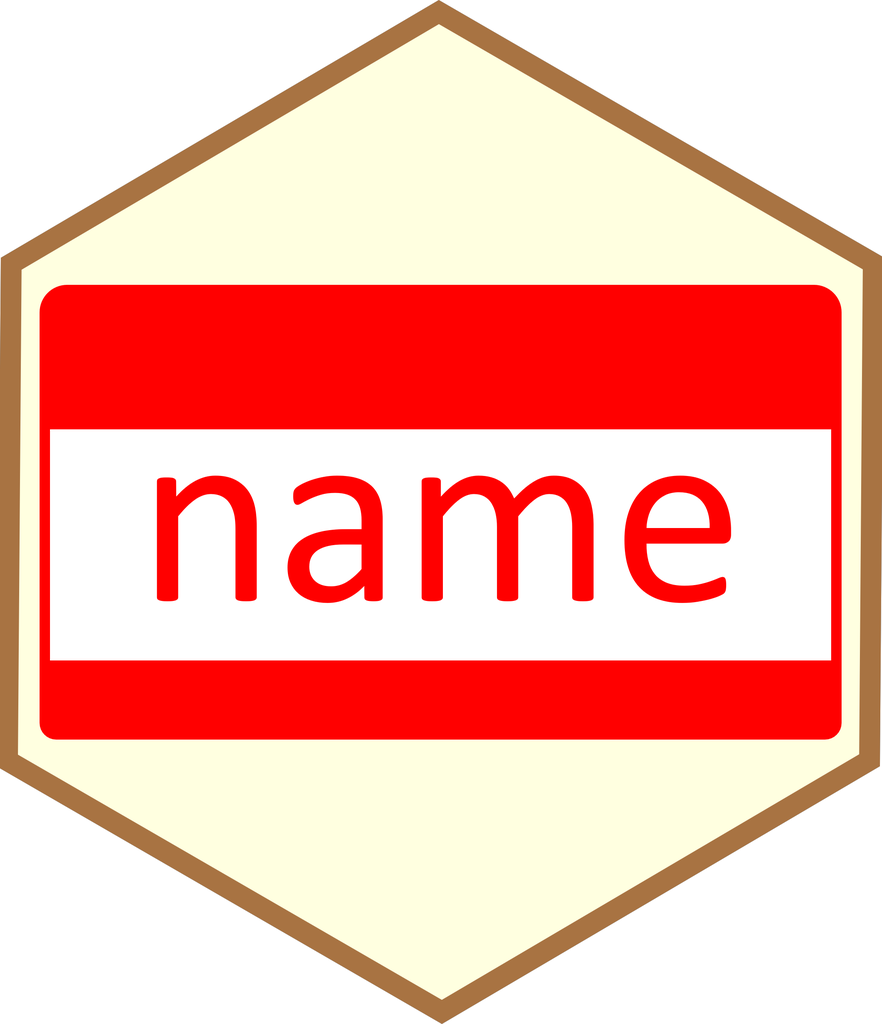

3,008

3,833

127.43%

redistmetrics

[figure not shown]

3,013

3,795

125.95%

ppmf

[figure not shown]

2,132

2,547

119.47%

ggredist

[figure not shown]

2,301

2,699

117.30%

dots

[figure not shown]

2,141

2,439

113.92%

jot

[figure not shown]

1,833

2,027

110.58%

censable

[figure not shown]

3,668

4,034

109.98%

redist

[figure not shown]

5,057

5,169

102.21%

cvap

[figure not shown]

3,151

3,126

99.21%

divseg

[figure not shown]

3,614

3,566

98.67%

PL94171

[figure not shown]

4,843

4,514

93.21%

# (Ongoing) Development in 2025

There’s always more to do. This year, I’m working on getting [`redistio`](https://github.com/christopherkenny/redistio) into research shape, with a lot of interest in using Kyle Walker’s new [mapgl](https://walker-data.com/mapgl/) as a modern alternative to leaflet. With a dissertation to finalize in the next few weeks and a postdoc in the fall, there’s a fair bit of focus on building out typesetting tools for academic writing, likely leading to some new packages related to Quarto and Typst in the near future.